## Lecture 5: Evidence from the CAPM and the APT (and related models)

# Tests of the CAPM

- To test the validity of a model, we need to test its predictions
- CAPM predicts
  1. A linear relationship between expected excess returns and beta
  2. No other variable has marginal explanatory power/alpha is zero
  3. The risk premium for Beta is positive and equal to the market risk premium
- These predictions can be tested in various ways

# Time series tests

- Jensen’s alpha: from the CAPM regression,

$$r_{i,t} - r_{f} = \alpha_{i} + \beta_{i}\bigg(r_{m,t} - r_{f}\bigg) + \epsilon_{i,t}$$

- Prediction: $\alpha_{i}$ should be jointly zero, i.e. $\alpha_{1} = 0, \alpha_{2} = 0, \ldots$
- Historical tests have not typically been favorable towards the CAPM
  - Reject that alphas are jointly zero (p=0.02) (Campbell, Lo, Mackinlay 1997)

# Time series tests

- Importance of time-series tests, however, is in their interpretation
- Can show joint tests of alpha are equivalent to the following:
  1. Find the Sharpe ratio of the market portfolio and compare it to the portfolio with the highest realized Sharpe ratio over a given period
  2. Time series tests provide statistical comparison of the predicted MVE (the market) and the actual MVE portfolio

# Time series tests

- Said otherwise, non-zero alphas suggest the market portfolio lags the realized maximum Sharpe ratio portfolios by more than the CAPM would suggest
- Generally, it is useful to think about CAPM tests/factor model tests as figuring out if the market/factor portfolios are “efficient”
  - Big question: which stocks should we overweight in the market portfolio to make it more efficient?

# Cross-sectional tests

- Cross-sectional tests have been somewhat more favorable
- Rather than regressing returns on returns, we now regress returns on betas
  - Hope to find that betas and returns line up as predicted by security market line
- Fama-Macbeth (1973) provides the standard framework for these tests

# Fama-Macbeth Cookbook

Two-step procedure:

1. Run time-series regressions to estimate beta for all stocks
   $$r_{i,t} - r_{f} = \alpha_{i} + \beta_{i}(r_{m,t} - r_{f}) + \epsilon_{i,t}$$
2. Run cross-section regression of average excess returns $r_{i} - r_{f}$ on estimated betas
   $$r_{i} - r_{f} = \lambda_{0} + \lambda_{1} \hat{\beta}_{i} + u_{i}$$

Prediction: $\lambda_{0} = 0$ and $\lambda_{1} = E(r_{m} - r_{f})$

# Fama-Macbeth Cookbook

- However, note that beta estimates are noisy
  - Regressing any variable on a noisy proxy will flatten the slope coefficient
- Why?
  - Imagine noise is added to x so that you observe x+e
  - True OLS coefficient is $\lambda_{1} = \frac{Cov(x,y)}{Var(x)}$
  - Estimated OLS coefficient is $\lambda_{1} = \frac{Cov(x+\epsilon,y)}{Var(x+\epsilon)} = \frac{Cov(x,y)}{Var(x) + Var(\epsilon)}$
- So, we expect any regression estimate of the security market line (SML) to be too flat.

# Fama-Macbeth Cookbook

- In response, we form portfolios of stocks and hope that idiosyncratic noise in beta estimates disappears
  - Why might this help?
- Portfolios are formed based on firm betas
  - Why not random assignment?
- Actual procedure:
  1. Each year, calculate betas for all firms (past five years data – 60 months)
  2. Form 10 decile portfolios based on estimated betas
  3. Calculate realized portfolio returns and betas for 10 portfolios

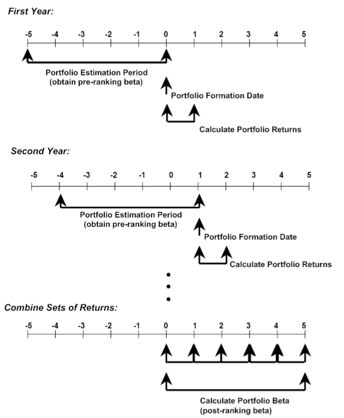

# Results

- Evidence is suggestive, but not completely consistent with CAPM
- Positive relation between beta and portfolio returns, but fitted line too flat (Fama, French, JEP 2004)

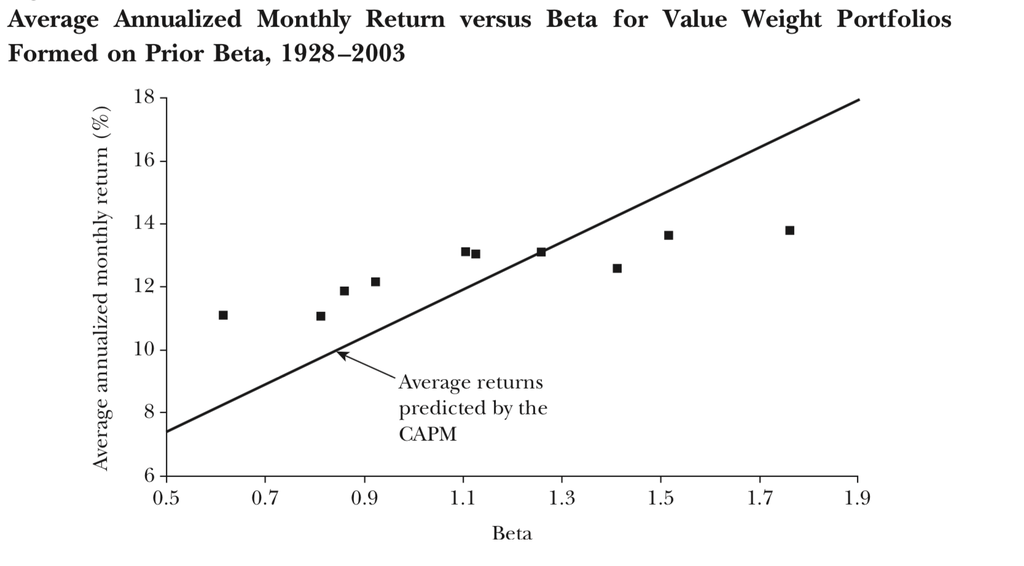

# Other predictions

- CAPM predicts no other measures of risk will predict cross-sectional returns
- In particular, CAPM says only covariance risk matters
  - What about idiosyncratic risk?
  - Fama-Macbeth (1973) control for idiosyncratic risk by including residual variances from firm time-series regressions in second-stage regression
  - Also beta squared

$$r_{i} - r_{f} = \lambda_{0} + \lambda_{1} \widehat{\beta}_{i} + \lambda_{2}\widehat{\beta}^{2}_{i} + \lambda_{3}\widehat{\sigma}^{2}_{e} + e_{i}$$

- They find that only $\beta$ seems to matter – it’s a linear relationship

# The search for anomalies begins

- However, we can go beyond beta-squared and residual variation to predict returns…
- For example:
  1. Earnings-to-price ratio $\longrightarrow$ high returns (Basu, 1977)
  2. Market cap $\longrightarrow$ low returns (Banz, 1981)
  3. Leverage $\longrightarrow$ high returns (Bhandari, 1988)
  4. Book-to-market $\longrightarrow$ high returns (Statman, 1980)
- All turn out to have predictive power over beta, in particular, size (market cap) and book-to-market
- So which wins in a race, beta or size?

# The search for anomalies begins

- Fama-French (1992) test this by creating double sorted portfolios
  - First, sort firms on size; then, sort on beta (cov with market)
  - Can do the same with book-to-market
- Set up a horse-race between beta and the two other factors
- If beta is a good predictor, it should predict even with a bin of similarly sized firms

# Average Returns, Post-Ranking Betas and Average Size on Portfolios (Fama-French 1992)

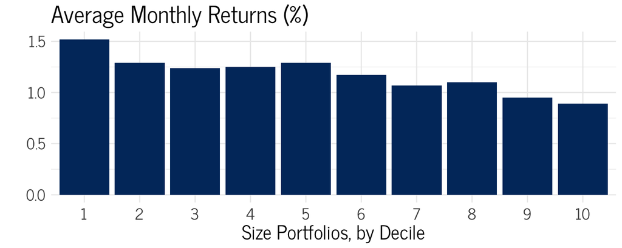

# Average Returns, Post-Ranking Betas and Average Size on Portfolios (Fama-French 1992)

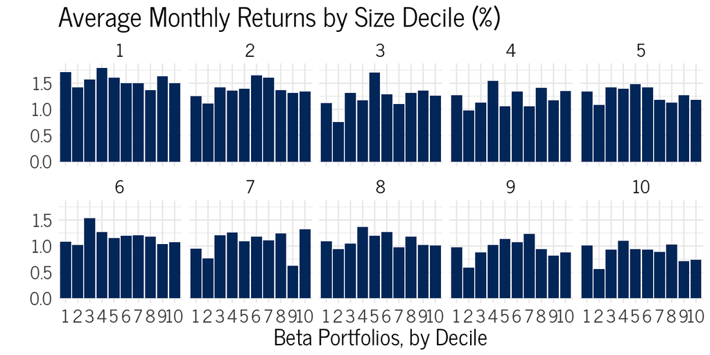

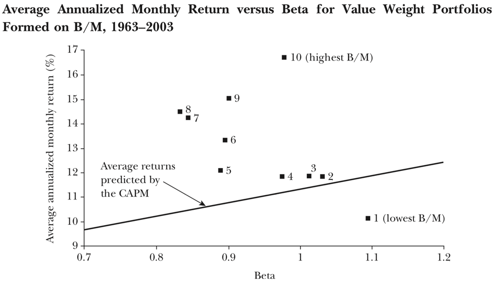

# Is Beta is dead?

- 30 years after its birth, hard to say that CAPM isn’t dead
- In reality, however, hard to say if CAPM or tests of the CAPM are flawed
- Roll’s critique:
  - Tests of the CAPM are infeasible because the market portfolio is unobservable
  - Tests of CAPM are only tests of the efficiency of the market proxy used

# Factor Models

- In spite of being largely credited with the temporary demise of the CAPM, Fama-French argue we need more flexible market proxies
- They advocate multiple factor models that capture the spirit of the CAPM
  - i.e. expected returns dictated by exposure to non- diversifiable risk
  - Size and book-to-market are not “characteristics” but proxies for economic risk factors

# Fama-French 3 factor model

$$r_{i}- r_{f} = \alpha + b_{i} \times (r_{m} - r_{f}) + s_{i}\times SMB + h_{i}\times HML + \epsilon_{i}$$
- to test

$$E(r_{i}- r_{f}) = b_{i} \times E(r_{m} - r_{f}) + s_{i}\times E(SMB) + h_{i}\times E(HML)$$

# Fama-French 3 factor model

$$E(r_{i}- r_{f}) = b_{i} \times E(r_{m} - r_{f}) + s_{i}\times E(SMB) + h_{i}\times E(HML)$$

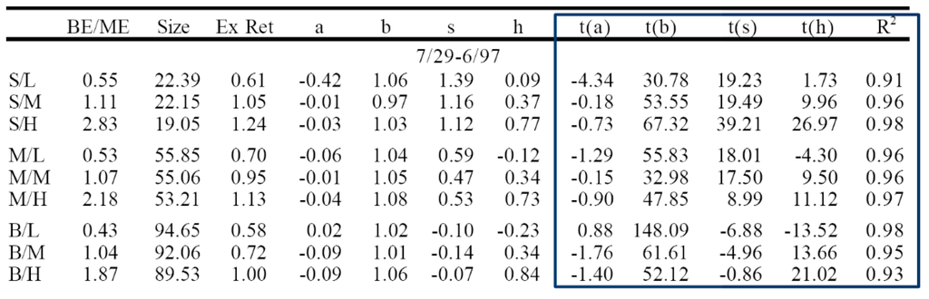

# Fama-French 3 factor model

- Claim: Size and value premia reflect exposure to risk captured in SMB and HML
- High returns which are not associated with risk factors should be arbitraged away
- Alphas of size and book-to-market portfolios jointly zero, once we control for SMB and HML risk factors
- This ensures the model is closer to a CAPM/APT story, but is source of some debate

# More factors (?!): Momentum

- Often times a fourth factor – momentum – is added to the portfolio
- Based on results that suggest that a strategy of buying winners and selling losers can earn a significant premium over a buy-and-hold strategy
- Note: again, we have taken a firm characteristic (recent success), made a portfolio out of it, and called it a “risk-factor”
  - Is this reasonable?

# Momentum Returns

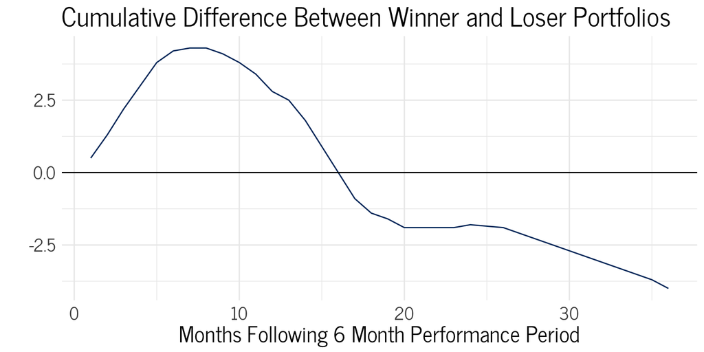

# More factors – Liquidity

- Illiquid stocks tend to offer higher returns
  - Can be measured based on bid-ask spreads
  - CAPM assumes away transaction costs
- Alternatively, we can characterize liquidity as a risk factor
  - Illiquidity of stocks is correlated – “systemic” liqudity
  - Systemic liquidity varies over time
  - Stocks exposed to liuqidity risk need to compensate investors with additional risk premia

# More factors—Liquidity

- Pastor and Stambaugh (2002) create a liquidity factor, $LIQ$
  - $LIQ_{t}$ is low when order flows have a large impact on prices
- We can add this factor to our 3 factor model:

$$E(r_{i} - r_{f}) = \beta_{i} E(r_{m} - r_{f}) + s_{i}E(SMB) + h_{i}E(HML) + l_{i}E(RP_{liq})$$

- Hedge funds sell exposure to liquidity risk
  - As long as you don’t need liquitiy when everyone else does, might as well get paid for it!

# Factors: risks or opportunities?

- Note the theme here
  - No shares are over/underpriced (almost)
  - Risk-premia paid on assets represent exposure to risk factors
  - Otherwise, “arbitrageurs” will quickly drive prices to equilibrium “correct” values
  - They need deep pockets!
- No free lunch $\rightarrow$ high returns = high risk exposure
- Different **kinds** of risk
  - Some institutions/investors prefer certain types of exposures

# The Factor Zoo

- We discussed many potential factors
  - Fama French 3 Factors, Momentum, Liquidity
- Why stop at 5?
  - Can continue to capture as many risks as possible!
- Why such a small number of factors?

# The Factor Zoo

- The estimation of systemic risk exposure relies on a limited amount of historical data
- Dumping in many historical risk factors that are correlated will give:
  - marginal gains
  - noisy estimates
- When you predict based on those estimates, you will get noisy output
  - Garbage in, garbage out!
- Many approaches to fix this

# Taming the Factor Zoo (Feng, Giglio and Xiu)

- A new approach: use machine learning to identify the “best” factors
- Feng Giglio and Xiu use “double-selection Lasso”, which will identify factors which capture the most important loadings in the cross-section
- They test 15 new contributed factors in the literature, and 4 out of 15 predictive beyond what was already studied in the literature.